# Respiration Analysis F1 Scallops 2021

Samuel Gurr

10/6/2021

### Merge master resp data frame with lengths

| Date | Channel | Filename | Lpc | Leq | Lz | alpha | Food | pH | Replicate | Chamber_tank | Number | Plate | Run | Fed_Unfed | Center | Length_um | Shell_tin_weight | tin_plus_shell | Tissue_tin_.weight | tin_plus_tissue | Dry_Shell_weight | Dry_Tissue_weight | whole_Dry_weight | Condition_Index | Instrument | Notes | filetype |
| --- | --- | --- | --- | --- | --- | --- | --- | --- | --- | --- | --- | --- | --- | --- | --- | --- | --- | --- | --- | --- | --- | --- | --- | --- | --- | --- | --- |
| 10/26/2021 | A1 | 20211026_resp_unfed.csv | -0.0113410 | -0.0157749 | -0.0152144 | 0.4 | unfed | 8.0 | A | 8_A | 1 | NA | 1_B | U | NA | 3228.52 | NA | NA | NA | NA | NA | NA | 2.237 | NA | SDR_24channel |  | SDR_data |
| 10/26/2021 | A3 | 20211026_resp_unfed.csv | -0.0334605 | -0.0314858 | -0.0372399 | 0.4 | unfed | 7.5 | A | 7.5_A | 1 | NA | 1_B | U | NA | 3851.85 | NA | NA | NA | NA | NA | NA | 3.422 | NA | SDR_24channel |  | SDR_data |
| 10/26/2021 | A5 | 20211026_resp_unfed.csv | -0.0206994 | -0.0204531 | -0.0204531 | 0.4 | unfed | 8.0 | B | 8_B | 1 | NA | 1_B | U | NA | 2976.68 | NA | NA | NA | NA | NA | NA | 2.140 | NA | SDR_24channel |  | SDR_data |
| 10/26/2021 | A6 | 20211026_resp_unfed.csv | -0.0110909 | -0.0114181 | -0.0114181 | 0.4 | unfed | 7.5 | D | 7.5_D | 1 | NA | 1_B | U | NA | 3250.48 | NA | NA | NA | NA | NA | NA | 2.515 | NA | SDR_24channel |  | SDR_data |
| 10/26/2021 | B1 | 20211026_resp_unfed.csv | -0.0091571 | -0.0089935 | -0.0089935 | 0.4 | unfed | 7.5 | A | 7.5_A | 2 | NA | 1_B | U | NA | 3218.16 | NA | NA | NA | NA | NA | NA | 2.377 | NA | SDR_24channel |  | SDR_data |
| 10/26/2021 | B3 | 20211026_resp_unfed.csv | -0.0101901 | -0.0110629 | -0.0110521 | 0.4 | unfed | 8.0 | C | 8_C | 1 | NA | 1_B | U | NA | 2167.19 | NA | NA | NA | NA | NA | NA | 0.622 | NA | SDR_24channel |  | SDR_data |

#### Visual diagnostic plots to correct poor data (3 data points to change..)

- View on github: Airradians_OA/RAnalysis/Output/Respiration/plots_alpha0.4_increm15sec/
- found three calls that inaccurately represent the rates of oxygen consumption
1. https://github.com/SamGurr/Airradians_OA/blob/master/RAnalysis/Output/Respiration/plots_alpha0.4_increm15sec/20210930_Plate_2_Run_2_C5_regression.pdf
- solution = call ‘Lz’ instead of the default Leq
2. https://github.com/SamGurr/Airradians_OA/blob/master/RAnalysis/Output/Respiration/plots_alpha0.4_increm15sec/20210930_Plate_2_Run_1_C1_regression.pdf
- solution = call ‘Lz’ instead of the default Leq
3. https://github.com/SamGurr/Airradians_OA/blob/master/RAnalysis/Output/Respiration/plots_alpha0.4_increm15sec/20210930_Plate_1_Run_2_C1_regression.pdf
- solution = we reran this at the end of the LoLin script for 0-20 minutes and got an Lpc -0.0296, insert this

```r
resp.data_merged[95,c(1:6)]  #  C1 RR_9.30.21_AM_Plate_2_Run_1.csv # -0.02890813    -0.0608251  -0.0608251 - Lz and Leq call better regression than Lpc
```

|  | Date | Channel | Filename | Lpc | Leq | Lz |
| --- | --- | --- | --- | --- | --- | --- |
| 95 | 9/30/2021 | C1 | RR_9.30.21_AM_Plate_2_Run_1.csv | -0.02890813 | -0.0608251 | -0.0608251 |

```r
resp.data_merged[111,c(1:6)] #  C5 RR_9.30.21_PM_Plate_2_Run_2.csv  0.029052351 -0.076034441    -0.076034441
```

|  | Date | Channel | Filename | Lpc | Leq | Lz |
| --- | --- | --- | --- | --- | --- | --- |
| 111 | 9/30/2021 | C5 | RR_9.30.21_PM_Plate_2_Run_2.csv | 0.02905235 | -0.07603444 | -0.07603444 |

```r
resp.data_merged[96,c(1:6)]  #  C1 RR_9.30.21_PM_Plate_1_Run_2.csv  0.011656487 0.011656487 0.011656487  - ommit this
```

|  | Date | Channel | Filename | Lpc | Leq | Lz |
| --- | --- | --- | --- | --- | --- | --- |
| 96 | 9/30/2021 | C1 | RR_9.30.21_PM_Plate_1_Run_2.csv | 0.01165649 | 0.01165649 | 0.01165649 |

```r
resp.data_merged[95,4] <- resp.data_merged[95,5] # 20210930_Plate_2_Run_2_C5_regression - Lz and Leq call better regression than Lpc
resp.data_merged[111,4] <- resp.data_merged[111,5] # 20210930_Plate_2_Run_1_C1_regression - Lz and Leq call better regression than Lpc
resp.data_merged[96,4] <- -0.0296 # 20210930_Plate_1_Run_2_C1_regression - plot shows noise after the 20 minutes mark, we reran this at the end of the LoLin script, insert here!

resp.data_merged[95,c(1:6)]
```

|  | Date | Channel | Filename | Lpc | Leq | Lz |
| --- | --- | --- | --- | --- | --- | --- |
| 95 | 9/30/2021 | C1 | RR_9.30.21_AM_Plate_2_Run_1.csv | -0.0608251 | -0.0608251 | -0.0608251 |

```r
resp.data_merged[111,c(1:6)]
```

|  | Date | Channel | Filename | Lpc | Leq | Lz |
| --- | --- | --- | --- | --- | --- | --- |
| 111 | 9/30/2021 | C5 | RR_9.30.21_PM_Plate_2_Run_2.csv | -0.07603444 | -0.07603444 | -0.07603444 |

```r
resp.data_merged[96,c(1:6)]
```

|  | Date | Channel | Filename | Lpc | Leq | Lz |
| --- | --- | --- | --- | --- | --- | --- |
| 96 | 9/30/2021 | C1 | RR_9.30.21_PM_Plate_1_Run_2.csv | -0.0296 | 0.01165649 | 0.01165649 |

#### Calculate blank rates, view means by day pH_treatment and instrument

- note: respiration rates were recorded using both SDR dish (24 channel) and Loligo 8-channel sensors - different blanks for each

| Date | pH | filetype | BLANK.mean_Lpc | BLANK.sd.Lpc | BLANK.mean_Leq | BLANK.mean_Lz | n |
| --- | --- | --- | --- | --- | --- | --- | --- |
| 10/26/2021 | 7.5 | LoLigo_data | 0.0056037 | 0.0046874 | 0.0058072 | 0.0056232 | 2 |
| 10/26/2021 | 7.5 | SDR_data | 0.0066671 | 0.0015381 | 0.0074908 | 0.0077362 | 4 |
| 10/26/2021 | 8.0 | LoLigo_data | 0.0032603 | 0.0027067 | 0.0032058 | 0.0035334 | 3 |
| 10/26/2021 | 8.0 | SDR_data | 0.0074689 | 0.0011264 | 0.0077981 | 0.0078353 | 4 |
| 9/14/2021 | 7.5 | LoLigo_data | 0.0037104 | 0.0007531 | 0.0038968 | 0.0037690 | 3 |
| 9/14/2021 | 8.0 | LoLigo_data | 0.0036354 | 0.0021660 | 0.0036815 | 0.0034417 | 4 |
| 9/30/2021 | 7.5 | SDR_data | 0.0135890 | 0.0069915 | 0.0142058 | 0.0117710 | 9 |
| 9/30/2021 | 8.0 | SDR_data | 0.0111450 | 0.0057253 | 0.0120854 | 0.0122455 | 9 |

#### Merge blanks with the master file by Date, pCO2 treatment, and filetype

- ‘filteype’ is only important here on 20211026 when both Loligo and SDR were used due to difference in size for fed (larger) and unfed animals

## Master Resp file ‘Resp.Master_OM’, with volumes and file types, etc. saved as ‘Calculated_Resp_Master.csv’

###### dplyr::mutate for the following:

- ‘volume’ of the different vessels throughout the fed*OA challenge
- ‘Age’
- ‘Fed_unfed’
- ‘pCO2’

### Relationship between Whole dry weight v. Shell length

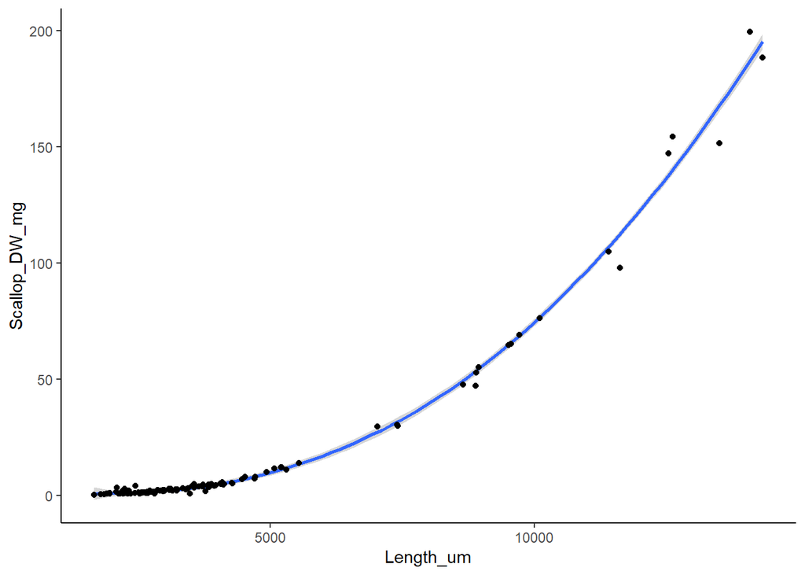

```r
Resp.Master_OM %>% ggplot(aes(x = Length_um, y = whole_Dry_weight)) +
                                geom_smooth(method = "loess") +
                                theme_classic() +
                                ylab("Scallop_DW_mg") +
                                xlab("Length_um") +
                                geom_point()
```

### Standardize rates as…

##### (1) shell length: umol L-1 O2 mm shell length hour-1

##### (2) whole dry weight: umol L-1 O2 g whole dry weight hour-1

note: this chunk calls the data that used the 8-channel loligo system and the SDR system to correct for total respiration chamber (vial/vessel, well, etc.) volume separately - loligo 8-channel on 9/14/21 = 2.2 ml vessels - SDR 24-channel on 9/3-/21 = 1.7 ml wells

```r
# Resp.Master_OM <- Resp.Master_OM[!is.na(Resp.Master_OM$Length_um),]

# NORMALIZED for Shell length
Resp.Master_OM$resp_µmol_L_mm_Length_hr <- (Resp.Master_OM$resp_umol_L_hr / # multiple by 1000 to convert mmol/ O2 to umol/L O2
              (Resp.Master_OM$Length_um/1000)) # normalize by Dry tissue weight  as to mg O2 L-1 g dry tissue weight-1

# NORMALIZED for Whole animal dry weight (g)
Resp.Master_OM$resp_µmol_L_g_hr <- (Resp.Master_OM$resp_umol_L_hr /
              (Resp.Master_OM$whole_Dry_weight/1000)) # normalize by Dry tissue weight  as to mg O2 L-1 g dry tissue weight-1


#write.csv(Resp.Master_OM, "C:/Users/samjg/Documents/Github_repositories/Airradians_OA/RAnalysis/Output/Respiration/Calculated_Resp_Master.csv")
write.csv(Resp.Master_OM, "C:/Users/samuel.gurr/Documents/Github_repositories/Airradians_OA/RAnalysis/Output/Respiration/Calculated_Resp_Master.csv")
```

### Plot the RAW rates by the size metrics here

#### Whole animal dry weight vs. raw respiration rate…

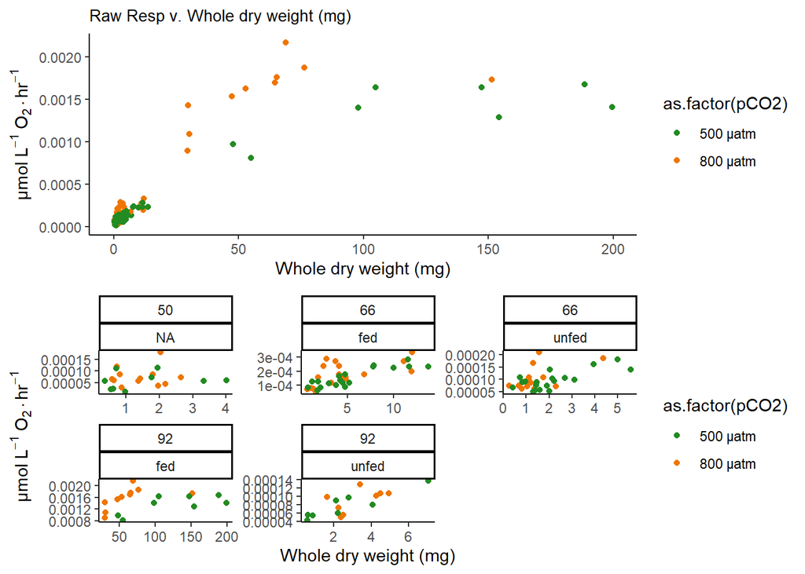

```r
# by WHOLE animal dry weight  :::::::::::::::::::::::::::::::::::::::::::::::::::::::::::::::::::::::::::::::::::::::::::::::::::::::::::::::::::::::::::::::::::

P_WholeDW_resp_all  <- Resp.Master_OM[!is.na(Resp.Master_OM$resp_umol_L_hr),] %>%
                          ggplot(aes(x = whole_Dry_weight, y = resp_umol_L_hr, color = as.factor(pCO2))) +
                            scale_color_manual(values=c("forestgreen","darkorange2"))+
                            geom_smooth(method = "lm", se=FALSE, color="black", formula = resp_umol_L_hr ~ whole_Dry_weight) +
                            theme_classic() +
                            theme(panel.grid.major = element_blank(), panel.grid.minor = element_blank(), plot.title = element_text(size=10))+
                            labs(title = "Raw Resp v. Whole dry weight (mg)", y = expression(μmol~L^{-1}~O[2]%.%hr^{-1})) +
                            xlab("Whole dry weight (mg)") +
                            geom_point()

P_WholeDW_resp_facet <- Resp.Master_OM[!is.na(Resp.Master_OM$resp_umol_L_hr),] %>%
                          ggplot(aes(x = whole_Dry_weight, y = resp_umol_L_hr, color = as.factor(pCO2))) +
                            scale_color_manual(values=c("forestgreen","darkorange2"))+
                            geom_smooth(method = "lm", se=FALSE, color="black", formula = resp_umol_L_hr ~ whole_Dry_weight) +
                            theme_classic() +
                            theme(panel.grid.major = element_blank(), panel.grid.minor = element_blank(), plot.title = element_text(size=10))+
                            labs(y = expression(μmol~L^{-1}~O[2]%.%hr^{-1})) +
                            xlab("Whole dry weight (mg)") +
                            geom_point() +
                            facet_wrap(~Age*Food, scales = "free")


# print in markdown file
ggarrange(P_WholeDW_resp_all, P_WholeDW_resp_facet,nrow = 2)
```

```r
# Export to pdf
ggarrange(P_WholeDW_resp_all, P_WholeDW_resp_facet,nrow = 2) %>%
  ggexport(filename = "C:/Users/samuel.gurr/Documents/Github_repositories/Airradians_OA/RAnalysis/Output/Respiration/RawRespiration_by_WholeDW.pdf")
```

#### Shell length vs. raw respiration rate…

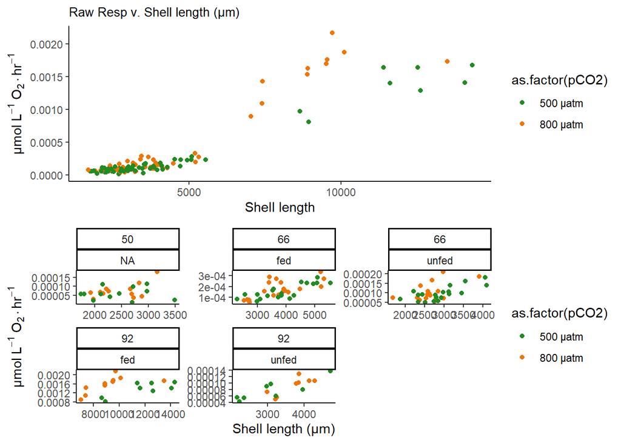

```r
# by Length :::::::::::::::::::::::::::::::::::::::::::::::::::::::::::::::::::::::::::::::::::::::::::::::::::::::::::::::::::::::::::::::::::

P_Length_resp_all <- Resp.Master_OM[!is.na(Resp.Master_OM$resp_umol_L_hr),] %>%
                        ggplot(aes(x = Length_um, y = resp_umol_L_hr, color = as.factor(pCO2))) +
                         scale_color_manual(values=c("forestgreen","darkorange2"))+
                          geom_smooth(method = "lm", se=FALSE, color="black", formula = resp_umol_L_hr ~ Length_um) +
                          theme_classic() +
                          theme(panel.grid.major = element_blank(), panel.grid.minor = element_blank(), plot.title = element_text(size=10))+
                          labs(title = "Raw Resp v. Shell length (μm)", y = expression(μmol~L^{-1}~O[2]%.%hr^{-1})) +
                          xlab("Shell length") +
                          geom_point()

P_Length_resp_facet <- Resp.Master_OM[!is.na(Resp.Master_OM$resp_umol_L_hr),] %>%
                        ggplot(aes(x = Length_um, y = resp_umol_L_hr, color = as.factor(pCO2))) +
                         scale_color_manual(values=c("forestgreen","darkorange2"))+
                          geom_smooth(method = "lm", se=FALSE, color="black", formula = resp_umol_L_hr ~ Length_um) +
                          theme_classic() +
                           theme(panel.grid.major = element_blank(), panel.grid.minor = element_blank(), plot.title = element_text(size=10))+
                          labs(y = expression(μmol~L^{-1}~O[2]%.%hr^{-1})) +
                          xlab("Shell length (μm)") +
                          geom_point() +
                          facet_wrap(~Age*Food, scales = "free")

# print in markdown file
ggarrange(P_Length_resp_all, P_Length_resp_facet,nrow = 2)
```

```r
# Export to pdf
ggarrange(P_Length_resp_all, P_Length_resp_facet,nrow = 2) %>%
  ggexport(filename = "C:/Users/samuel.gurr/Documents/Github_repositories/Airradians_OA/RAnalysis/Output/Respiration/RawRespiration_by_Length.pdf")
```

### All Respiration data - Mean standard error plots

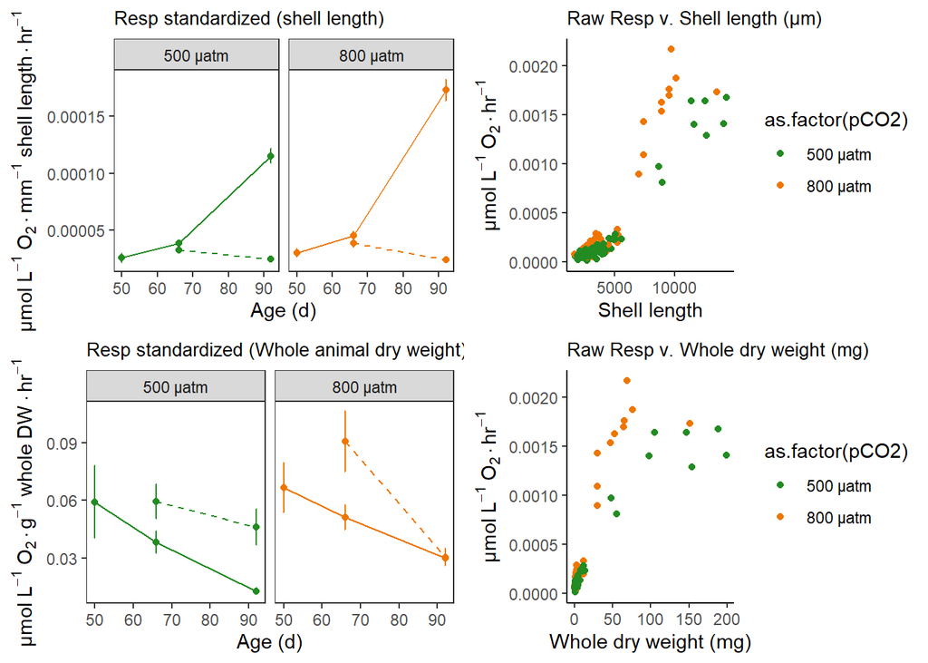

```r
RespSumTab_Len      <- Resp.Master_OM[!is.na(Resp.Master_OM$resp_µmol_L_mm_Length_hr),] %>%
            summarySE(measurevar="resp_µmol_L_mm_Length_hr", groupvars=c("Age", "pCO2", "Fed_Unfed"))
RespSumTab_Len$pCO2 <- factor(RespSumTab_Len$pCO2, c("500 μatm","800 μatm"))
## Use geom_line and geom_point to plot over time
Resp_LengthStand    <- ggplot(data=RespSumTab_Len, aes(x=Age, y=resp_µmol_L_mm_Length_hr, color=pCO2)) +
            geom_line(aes(linetype = factor(Fed_Unfed)), size = 0.5) +
            geom_point()+
            scale_color_manual(values=c("forestgreen","darkorange2"))+
            geom_errorbar(aes(ymin=resp_µmol_L_mm_Length_hr-se, ymax=resp_µmol_L_mm_Length_hr+se), width=.2,
                          position=position_dodge(.1))+
            theme_bw() +
            theme(panel.grid.major = element_blank(), panel.grid.minor = element_blank(), plot.title = element_text(size=10))+
            scale_x_continuous(name ="Age (d)") +
            labs(title = "Resp standardized (shell length)",
                 y = expression(μmol~L^{-1}~O[2]%.%mm^{-1}~shell~length%.% hr^{-1})) +
            scale_linetype_manual(values = c("High food" = "solid", "Low food" = "dashed"))  +
            theme(legend.position="none") +
            # facet_wrap(~factor(Fed_Unfed, level = c('Low food', 'High food')))
            facet_wrap(~pCO2)



RespSumTab_DW      <- Resp.Master_OM[!is.na(Resp.Master_OM$resp_µmol_L_g_hr),] %>%
          summarySE(measurevar="resp_µmol_L_g_hr", groupvars=c("Age", "pCO2", "Fed_Unfed"))
RespSumTab_DW$pCO2 <- factor(RespSumTab_DW$pCO2, c("500 μatm","800 μatm"))
## Use geom_line and geom_point to plot over time
Resp_DryWgtStand   <- ggplot(data=RespSumTab_DW, aes(x=Age, y=resp_µmol_L_g_hr, color=pCO2)) +
          geom_line(aes(linetype = factor(Fed_Unfed)), size = 0.5) +
          geom_point()+
          scale_color_manual(values=c("forestgreen","darkorange2"))+
          geom_errorbar(aes(ymin=resp_µmol_L_g_hr-se, ymax=resp_µmol_L_g_hr+se), width=.2,
                        position=position_dodge(.1))+
          theme_bw() +
          theme(panel.grid.major = element_blank(), panel.grid.minor = element_blank(), plot.title = element_text(size=10))+
          scale_x_continuous(name ="Age (d)") +
          labs(title = "Resp standardized (Whole animal dry weight)",
               y = expression(μmol~L^{-1}~O[2]%.%g^{-1}~whole~DW%.% hr^{-1})) +
          scale_linetype_manual(values = c("High food" = "solid", "Low food" = "dashed"))  +
          theme(legend.position="none") +
          # facet_wrap(~factor(Fed_Unfed, level = c('Low food', 'High food')))
          facet_wrap(~pCO2)

ggarrange(Resp_LengthStand,P_Length_resp_all,
          Resp_DryWgtStand,P_WholeDW_resp_all, ncol = 2,nrow = 2)
```

```r
ggarrange(Resp_LengthStand,P_Length_resp_all,
          Resp_DryWgtStand,P_WholeDW_resp_all, ncol = 2,nrow = 2) %>%
  ggexport(filename = "C:/Users/samuel.gurr/Documents/Github_repositories/Airradians_OA/RAnalysis/Output/Respiration/All_Respiration_normalized.pdf")
```

# Analysis

### 9/14/2021 F1 juvenile scallops

**About** - two pCO2 treatments - **before** we culled and started the food limitation trials

##### number of replicates for analysis…

| Chamber_tank | n() |
| --- | --- |
| 7.5_A | 3 |
| 7.5_B | 3 |
| 7.5_C | 3 |
| 7.5_D | 3 |
| 8_A | 3 |
| 8_B | 3 |
| 8_C | 3 |
| 8_D | 3 |

### 9/14/2021 linear model, diagnostics, and plots

#### Length standardized

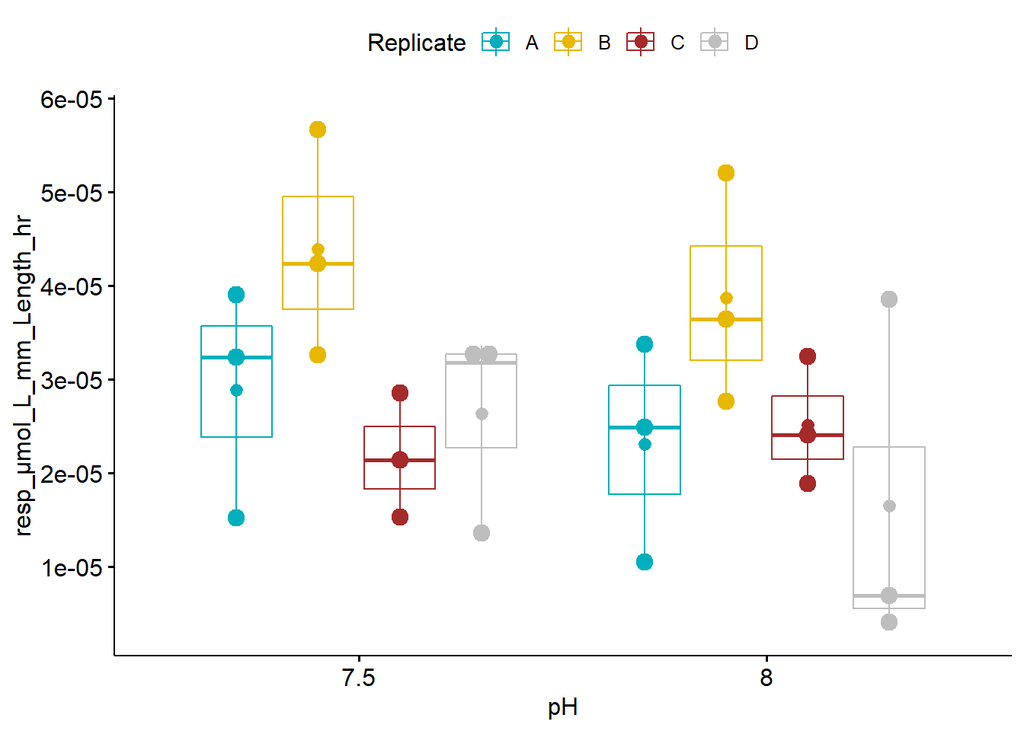

```r
# Shell length standardized (SL) ::::::::::::::::::::::::::::::::::::::::::::::::::::::::::::::::::::::::::::::::::::::::::::::::::::::::::::

library("ggpubr")
Resp914_Length_reps<- ggboxplot(Resp_0914, x = "pH", y = "resp_µmol_L_mm_Length_hr", color = "Replicate",
                              add = c("mean_se", "dotplot"),
                              palette = c("#00AFBB", "#E7B800", "brown", "grey"))
Resp914_Length_reps
```

```r
# models..
require(nlme)
# Linear mixed effects model with random effect of Replicate
LMEmod_0914_SL<-lme(resp_µmol_L_mm_Length_hr ~ pCO2, random=~1|Replicate, data=Resp_0914)
# |     &nbsp;      | numDF | denDF | F-value |  p-value  |
# |:---------------:|:-----:|:-----:|:-------:|:---------:|
# | **(Intercept)** |   1   |  19   |  38.42  | 5.912e-06 |
# |    **pCO2**     |   1   |  19   | 0.8712  |  0.3623   |
pander(anova(LMEmod_0914_SL), style='rmarkdown')
```

|  | numDF | denDF | F-value | p-value |
| --- | --- | --- | --- | --- |
| **(Intercept)** | 1 | 19 | 38.42 | 5.912e-06 |
| **pCO2** | 1 | 19 | 0.8712 | 0.3623 |

```r
# linear model without the random effect of Replicate
LMmod_0914_SL <- aov(lm(resp_µmol_L_mm_Length_hr~pCO2,data=Resp_0914))
# |    &nbsp;     | Df | Sum Sq | Mean Sq | F value | Pr(>F) |
# |:-------------:|:--:|:------:|:-------:|:-------:|:------:|
# |   **pCO2**    | 1  | 67.77  |  67.77  | 0.6327  | 0.4348 |
# | **Residuals** | 22 |  2356  |  107.1  |   NA    |   NA   |
pander(summary(LMmod_0914_SL), style='rmarkdown')
```

Analysis of Variance Model

|  | Df | Sum Sq | Mean Sq | F value | Pr(>F) |
| --- | --- | --- | --- | --- | --- |
| **pCO2** | 1 | 1.135e-10 | 1.135e-10 | 0.6327 | 0.4348 |
| **Residuals** | 22 | 3.946e-09 | 1.794e-10 | NA | NA |

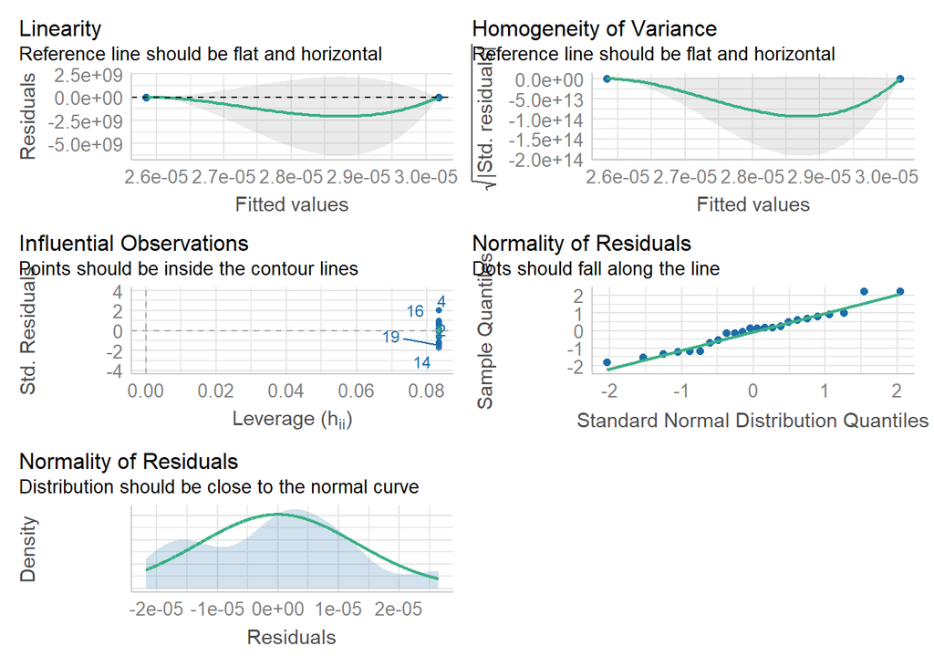

```r
check_model(LMmod_0914_SL) # observe the diagnostics of the model
```

```r
shapiro.test(residuals(LMmod_0914_SL)) #  normal - 0.3875
```

```
##
##  Shapiro-Wilk normality test
##
## data:  residuals(LMmod_0914_SL)
## W = 0.95735, p-value = 0.3875
```

```r
leveneTest(LMmod_0914_SL) # good - 0.6186
```

|  | Df | F value | Pr(>F) |
| --- | --- | --- | --- |
| group | 1 | 0.2549469 | 0.6186337 |
|  | 22 | NA | NA |

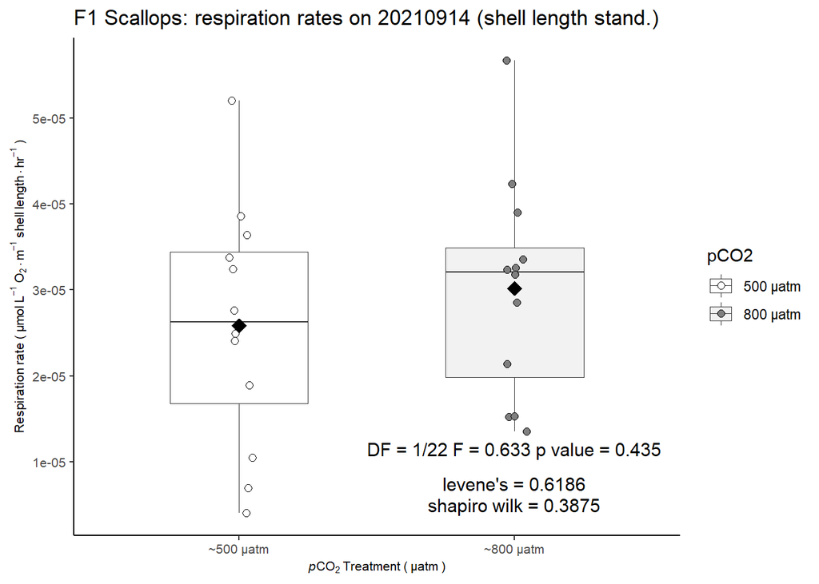

```r
DF   <- paste( (summary(LMmod_0914_SL)[[1]][["Df"]])[1], (summary(LMmod_0914_SL)[[1]][["Df"]])[2], sep = '/')
Fval <- (summary(LMmod_0914_SL)[[1]][["F value"]])[1]
pval <- (summary(LMmod_0914_SL)[[1]][["Pr(>F)"]])[1]


Resp914_Length <- ggplot(Resp_0914, aes(x = factor(pCO2, level = c('500 μatm', '800 μatm')), resp_µmol_L_mm_Length_hr , fill = pCO2)) +
                    theme(panel.grid=element_blank()) +
                    geom_boxplot(size=0.2, width=0.5, alpha=0.1, aes(fill=pCO2)) +
                    scale_fill_manual(values=c("white","grey50")) +
                    geom_point(shape = 21, size = 2, position = position_jitterdodge(jitter.width = 0.1)) +
                    theme_classic() +
                    scale_x_discrete(labels= c('~500 μatm', '~800 μatm')) +
                   # scale_y_continuous(expand = c(0, 0), limits = c(0, 2)) +
                    labs(title = "F1 Scallops: respiration rates on 20210914 (shell length stand.)",
                         y = expression(Respiration~rate~"("~μmol~L^{-1}~O[2]%.%m^{-1}~shell~length%.% hr^{-1}~")"),
                         x = expression(italic(p)*CO[2]~Treatment~"("~μ*atm~")")) +
                    theme(axis.text=element_text(size=8),
                          axis.title=element_text(size=8,face="bold")) +
                     stat_summary(fun.y=mean, geom="point", shape=18, size=4, color="black", fill="white") +
                     annotate("text", x=2, y=0.000005, size = 4, label = "shapiro wilk = 0.3875") +
                     annotate("text", x=2, y=0.0000075, size = 4, label = "levene's = 0.6186") +
                     annotate("text", x=2, y=0.0000115, size = 4, label= paste('DF =',DF,'F =', signif(Fval, digits=3), 'p value =', signif(pval, digits=3), sep=" "))
Resp914_Length
```

```r
# Export to pdf
ggarrange(Resp914_Length,Resp914_Length_reps,nrow = 2) %>%
  ggexport(filename = "C:/Users/samuel.gurr/Documents/Github_repositories/Airradians_OA/RAnalysis/Output/Respiration/20210914_figs_tables/20210914_respiration_length.standardized.pdf")
```